# Recombination Landscapes in Angiosperms

2020-07-01

Download this page in a pdf format.

# 1 Introduction

Meiotic recombination is a crucial mechanism for eukaryotes, involved in genome evolution. Recombination influences the rate of loss of genetic variation and the efficacy of selection. Because recombination enhances genetic shuffling during the meiosis, it constantly produces new genetic combinations and enhances genetic diversity in populations. Furthermore, recombination decreases the genetic linkage between loci, hence counteracting interferences between linked loci (the Hill-Robertson interference) and enhancing the efficacy of selection (Hill and Robertson, 1966). Interestingly, recombination heterogeneity has implications on population differentiation (Burri et al., 2015). By reducing allelic correlations, the recombination increases genetic variation and efficiently purge deleterious mutations. Besides these indirect consequences of recombination (i.e. decrease of the linkage disequilibrium and a more efficient selection), meiotic recombination events also imply direct effects on genomes, such as molecular consequences (Webster and Hurst, 2012). DNA double strand breaks (DSB) and repair mechanisms of homologous sequences are generally biased toward GC nucleotides in a lot of species (Duret and Galtier, 2009; Galtier et al., 2001; Glémin et al., 2015; Rousselle et al., 2019). Genomic features such as gene density or nucleotide composition (e.g. GC content) vary greatly, and recombination is suspected to directly interact with many genome evolutionary processes, such as transposable elements (TE), GC-biased gene conversion (gBGC) or even methylation (Apuli et al., 2019; Gaut et al., 2007; Kent et al., 2017; Tiley and Burleigh, 2015).

[figure not shown]

Figure 1.1: Model of recombination between two homologous strands in red and blue. The two red strands are broken and sometimes one is pairing with the homologous strand in blue. After the formation of a heteroduplex with paired strands, the double strand break (DSB) can lead to a crossover, with exchange of DNA material between the two paired strands. The repair of mismatches in base composition between strands (MMR) is biased toward GC bases over AT.

Reliable estimates of local recombination rates along the genome, also defined as recombination landscapes, are highly relevant in the study of genome evolution, as they may help to understand how species respond to selection and adapt to their environment. Variation in Genome-Wide Recombination Rates (GwRR) have been recently reviewed in Eukaryotes, in regard to the many drivers of recombination, from individual to distantly related species levels (Stapley et al., 2017). Moreover, the heterogeneity of recombination can vary depending on the genomic scale considered. The number of specific studies on fine-scale recombination landscapes targeting the distribution of hotspots is growing (Drouaud et al., 2013; Hellsten et al., 2013; Marand et al., 2019; Murat et al., 2010). Yet, the review of Stapley et al. (2017) argued the need for a broad-scale study of the recombination landscapes, i.e. the distribution of the recombination rate within the chromosome. A recent meta-analysis roughly explored variation in recombination landscapes across Eukaryotes but on a reduced subset of plants (Haenel et al., 2018). Evidences are now accumulating on how and why recombination landscapes vary between species, populations, individuals, chromosomes or even sexes (Bauer et al., 2013; Charlesworth, 2017; Petit et al., 2017; Ritz et al., 2017; Sardell and Kirkpatrick, 2019). Moreover, the production of new data is a prerequisite before testing theories and models (Dapper and Payseur, 2017). For example, Monnahan et al. regretted that no recombination landscapes exist for *A. arenosa* to use it as covariates in regression modeling for population genomic (Monnahan et al., 2019).

Diversity of Angiosperms is impressive and they are the largest phylogenetic group of plants in terrestrial landscapes. As many as 400,000 species (~14,000 genera) grow in all environmental conditions, from arctic to tropical biomes (Soltis et al., 2018). Besides, seeds played a crucial role in the development of agriculture. Recombination is involved in domestication processes (Dreissig et al., 2019; Ross-Ibarra, 2004). Crop improvement is based on recombination and selecting QTL in regions of high linkage can be challenging (Lambing et al., 2017; Wang and Copenhaver, 2018). In such a context, recombination landscapes may be a useful tool for the rapid assessment of large clusters of QTL with a strong linkage resisting to artificial selection (Crouzillat D., personal communication). Thus, the comparison of recombination and genomic landscapes is promising in the understanding of patterns of recombination at a large phylogenetic scale for a taxonomic group of high ecological and sociological importance.

Angiosperms present a high variation of genome architecture, with a 55-fold variation in genome size and 10-fold in number of chromosomes, associated to frequent chromosomal rearrangements (e.g. chromosomal inversions, gene duplications, polyploidisation). Heterogeneity in recombination rates has been assessed at multiple levels for Angiosperms, and the interspecific variance of averaged recombination rates is one of the highest among eukaryotes (Stapley et al., 2017). Intraspecific variance between populations or hybrids has also been assessed for maize or *Brassicacea* (Bauer et al., 2013; Pelé et al., 2017). Moreover, recombination landscapes are also varying at a chromosomal level. Maize, *Arabidopsis thaliana* and European Aspen show clear variation in recombination rates along the chromosome (Apuli et al., 2019; Bauer et al., 2013; Colome-Tatche et al., 2012). Genomic inversions in mutants, that are not rare in plants, can suppress recombination in a whole chromosome (Termolino et al., 2019). The recombination rates vary significantly between the sub-genomes of the polyploid cotton (Shen et al., 2017). Besides, the study of nucleotide composition in plants is still recent compared to metazoans, and recombination landscapes still need to be explored across the Angiosperms taxa. At the genic level, a lot of attention has been given to the PRDM9 zinc-finger protein, which has been identified as a driver of recombination hotspot initiation in mammals (Baudat et al., 2013). Yet, this protein seems exclusive to metazoans and recombination initiation in Angiosperms more likely occurs in gene promoters or gene 5’ end (Choi and Henderson, 2015). Initiation in promoters seems to be the ancestral mechanism governing the distribution of recombination hotspots (Auton et al., 2013; Axelsson et al., 2012; Baker et al., 2017). Indeed, the local gene density along the chromosome seems to drive heterogeneity in recombination rates (Shen et al., 2017).

### Hypotheses and design

I’m willing to investigate the global question of how and why recombination rates are globally distributed along the chromosomes in Angiosperms? And what are the implications for genome evolution (e.g. GC content, gene density)? We hypothesized that recombination is not randomly distributed along the chromosome for most Angiosperms (i.e. CO distribution is not uniform along the chromosome), with significant variations of patterns among species. However, it is not clear how global patterns are structured and they need to be described. I will respond to the question in three axes.

Firstly, I will study the heterogeneity of recombination landscapes across species and chromosomes to see if global patterns are similar or varying between species/chromosomes. The design of my first axis will be to estimate and describe the broad-scale landscapes of recombination rate along the chromosome in as much species as possible. In order to achieve this, I will use the Marey map method described in Rezvoy et al. (2007). It relies on interpolation methods to estimate the local derivatives of the genetic distances (cM) as a function of physical distances (Mb), that is the local recombination rate (cM.Mb$^{-1}$). Once published in an open database, these recombination landscapes should be a great advance for the scientific community that would like to test evolutionary hypotheses on a rich broad-scale dataset compared to genomic or ecological data of their own (e.g. life history traits, reproductive systems). Moreover, I intend to describe and characterize the structure of recombination landscapes, as we expect there is a clear structure. It is well known that recombination rates are not uniform within chromosomes. However, evidences of heterogeneity and structure among a large sample of species are lacking, and there is very few statistical descriptions of the structure (e.g. decomposition of genomic sequences in segments, autocorrelation). Summary statistics should be a crucial part of statistical testing to disentangle factors shaping the recombination landscape, as the comparison of whole landscapes between multiple species/chromosomes may rapidly become tedious. Consequently, I will have to find the most relevant metrics to describe recombination landscapes.

Furthermore, I will make a link between recombination landscapes and genome evolution. I will test for links between heterogeneity, structure and the numerous factors expected to drive or be driven by recombination. Based on a comparative genomic approach, we’ll try to assemble a large dataset of Angiosperms recombination landscapes to assess the variation of the recombination rate as a function of genome architecture and genomic features.

Indeed, in a second axis, I will explore correlations between variations in recombination landscapes and genome architecture. It is clear that the recombination rate is correlated to chromosome architecture (e.g. chromosome size, centromere position) (Blackmon et al., 2019; Stapley et al., 2017). Given the assumption that at least one crossover is mandatory during meiosis, one can expect a higher recombination rate in smaller chromosomes. The negative correlation between the chromosome size and the mean recombination rate is clearly established (Kawakami et al., 2014; Ross-Ibarra, 2007; Tiley and Burleigh, 2015). However, there is fewer evidences on how it could affect the shape of the recombination landscape. Given that recombination is concentrated in telomeres, away from centromeres, we can hypothesize longer pericentromeric regions of low recombination in long chromosomes than shorter ones and a positive correlation between the distance to the centromere and the recombination rate (Backstrom et al., 2010). Furthermore, centromeric and pericentromeric regions usually have a very low recombination rate compared to the rest of the genome, although *Medicago truncatulata* showed higher recombination rates close to the centromere (Mézard, 2006; Paape et al., 2012; Shen et al., 2017). Sometimes, recombination is suppressed within the centromere (Sardell et al., 2018). Recombination landscape might be separated in two kind of regions. Those with heterogeneity in recombination rates varying around the average recombination rate, and a pericentromeric region with very low or even null recombination rates. Hence, shape of recombination landscapes might be profoundly affected by the centromere location, that is not always at the center of the chromosome. Moreover, because recombination occurs mainly in promoter regions, regions with higher gene densities might show higher recombination rates, due to the larger number of promoters where to initiate recombination (Wijnker et al., 2013), and the distribution of genes along the chromosome should greatly influence the recombination landscape. I will explore correlations as well between recombination heterogeneity and genome organization, such as gene size, intron size and repeat density. Indeed, a negative correlation is expected between recombination rates and highly-repeated motifs, as in *Populus* species (Apuli et al., 2020). Based on this hypotheses, I expect to confirm such correlations across a large panel of Angiosperms.

Ultimately, the third axis will be the study of broad-scale correlations between recombination rates and genomic features (e.g. GC content), combined to the detection of hotspots in polymorphism data to confirm such correlations at the gene-scale in a subset of the most contrasting species. Variation in base composition has long been studied in Angiosperms and the structure of the genome have been empirically assessed since a long time (Clément et al., 2017; Matassi et al., 1989; Salinas et al., 1988). Impacts of the recombination on nucleotide substitutions is clear in the human genome, and evidences are accumulating that recombination drives the evolution of GC-Content for a large range of species (Clément et al., 2017; Duret and Arndt, 2008; Lesecque et al., 2013; Meunier and Duret, 2004; Pessia et al., 2012; Serres-Giardi et al., 2012; Weber et al., 2014). We hypothesized that heterogeneity in recombination rates drives the global pattern of GC content and codon usage in chromosomes via the GC-biased gene conversion (gBGC), hence we can expect positive correlations between recombination rates and GC content/codon usage (Clément et al., 2015; Glémin et al., 2014; Mazumdar et al., 2017; Serres-Giardi et al., 2012; Wijnker et al., 2013). However, gBGC has been assessed in mammalian studies and it is not clear how gBGC is acting in Angiosperms (Wang and Copenhaver, 2018). Significant positive correlations between recombination and GC content have been assessed in some plant species yet many exceptions exist (Clément et al., 2017; Glémin et al., 2014; Marais et al., 2004). We expect to find two contrasting patterns in recombination landscapes, whether or not the recombination rate is correlated to nucleotide composition. Finally, subsequently to this extensive description of recombination patterns, further integration of polymorphism data could help to resolve hypotheses on the link between recombination and GC distribution in the genome, that are not achievable with pedigree data due to its nature or low resolution. Moreover, such an increase in novel data could lead to explore eco-evolutionary hypotheses, like the importance of domestication processes in recombination evolution. Besides, a population genomic approach based on polymorphism data may open a vast field of novel evolutionary questions that could be investigated later.

# 2 Material and methods

### How to estimate recombination rates?

Meiotic recombination is typically studied through the transmission of polymorphic DNA markers. The design is to examine the patterns of segregation/independence between markers. Two loci are not independent when they are not randomly segregated during meiosis. A higher correlation between two loci (i.e. linkage disequilibrium) demonstrates a higher probability to be transmitted together to the progeny, hence lower recombination between these two markers. It has to be noted that there exists two ways of solving a Double Strand Break (DSB) in DNA sequences, although only DSBs resolved in crossover can be observed in genetic data. DSBs open a gap in the DNA sequence and engage the pairing between homologous chromosomes. The repair of this gap can lead to a crossover (CO) or a non-crossover (NCO), depending on the occurrence of a Double Holliday Junction (DHJ) or not. A CO results in the exchange of a DNA strand between homologous chromosomes (hence producing a novel haplotype), while NCO are resolved without physical exchange of DNA. Thus, it is clear that only CO can be observed in the distribution of DNA markers, although some methods allow to estimate NCO with genetic data (Li et al., 2019; Wijnker et al., 2013). What we call recombination rate is more exactly the crossover rate in our context.

There exist three main methods to estimate the recombination rate with polymorphic DNA markers, depending on the desired genomic resolution. (1) The first one uses pedigree data in crossings between homozygotes and is restricted to scales of 1Mb-100kb, depending on the number of meiotic events surveyed. Genetic maps of distances between markers in centiMorgans are inferred from genotyped markers and segregation probabilities during meiosis (Kosambi, 2016). Recombination rates (cM.Mb$^{-1}$) are then estimated from the curve of genetic distances (cM) expressed as a function of physical distances (Mb) (Dukić et al., 2016). (2) Sperm typing allows finer scales (1-10kb), although gathering data is laboratory intensive, limited to short targeted genomic regions and estimates are male-specific. A huge pool of sperm is genotyped and the recombination rate is estimated from frequencies of marker haplotypes (Holloway et al., 2006). (3) Finally, many statistical frameworks have been developped to estimate recombination rates from patterns of linkage disequilibrium in polymorphism data (population data) (Auton and McVean, 2007; Fearnhead, 2006; Fearnhead and Donnelly, 2001; Hey and Wakeley, n.d.; Stumpf and McVean, 2003; Wall and Stevison, 2016). LD-based methods estimate the historical population recombination rate involving a huge number of meiotic events, hence they have a fine-scale resolution (1-10kb) and a high power for detecting hotspots of recombination. However, the estimated parameter is the product of the effective population size $N{_e}$ and the recombination rate $r$, and recombination landscapes with scaled population parameters 4$N{_e}r$ are not easily comparable between species. Ultimately, estimates of recombination rates can vary with the genomic scale of the method employed (Dapper and Payseur, 2017).

The exploration of the various methods used to infer the recombination rate from genetic and genomic data would require an extensive review. Estimates of recombination rates help to realistically parameterize simulations (e.g. SLiM can take a recombination map as parameter) or to integrate more data in both theoretical genomic models and empirical molecular studies (Dapper and Payseur, 2017; Haller and Messer, 2019). The rapid growth of large genomic dataset in pedigree studies and the increasing availability of reference genomes make the pedigree data approach more relevant than ever in comparative genomics. Moreover, polymorphism data and LD-based approaches benefits of development of advanced statistical frameworks in the genomic field (e.g. Bayesian models, Machine Learning technics) and progresses in Next-Generation Sequencing (NGS) to generate data (Adrion et al., 2019). Although the pedigree data approach rely on simpler statistical methods, power and sensitivity of the method have not yet been completely treated. Besides, methods emerged recently to estimate recombination rates directly from the count of the crossover distribution and a synthesis of promising individual developments could really benefit to the scientific community involved in the study of recombination heterogeneity (Comeron et al., 2012; Petit et al., 2017).

For the pedigree approach we adopted (method 1), the recombination rate was historically a simple decomposition of the genetic map in moving windows in which the genetic size was divided by the physical size (Kong et al., 2002). However, the Marey map is now a common method to visualize the distribution of the recombination along the chromosome (Marey map plots, as described below) and estimate the local recombination rate at broad-scale using interpolation methods to fit a curve to the Marey map (Rezvoy et al., 2007). We chose this approach for its advantages, that are sex-specific maps (recombination is known to vary between sexes), accessibility of the data to constitute a large dataset (the method only require a genetic map and a reference genome) and a recombination rate that is not scaled by the effective population size (unlike LD-based approaches). LD-based approaches are more efficient at fine-scale, especially for detecting hotspots of recombination, yet we are more concerned about global patterns of recombination, considering the recombination structure on the whole chromosome. Moreover, despite its high resolution, sperm typing was not appropriate as it is laboratory intensive and restricted to short targeted gneomic regions and few model organisms. However, the Marey map approach have some limits. The recombination is observed in a single generation of a small population (hundreds of individuals), hence only a reduced subset of meiotic recombination events are observed, and many putative recombination events are missed. The resolution of the recombination landscape is limited to 100kb in high density genetic maps with a large number of crossings or even 1Mb in lower density genetic maps. Furthermore, few studies tried to evaluate the quality and reliability of interpolation made, and ultimately, estimates of recombination rates may be biased in many ways (e.g. overfitting, statistical artifacts) although interpolation methods were specifically improved to deal with it (Berloff et al., 2002). Uncertainty of estimations is rarely assessed in studies, yet final estimates are the product of multiple uncertainties. Marker genotyping, marker mapping, marker anchoring on the reference genome, curve interpolation and finally computing derivatives on this interpolated curve are all introducing errors in the process, that are not trivial to correct and not so often taken in account (Apuli et al., 2019; Bauer et al., 2013; DeWan et al., 2002a; Fiston-Lavier et al., 2010; van Muijen et al., 2017). Finally, the way we estimate recombination rates may greatly benefit of simulation studies to investigate power and sensitivity of our method. Besides, once the Marey map approach for broad-scale patterns will be set up, I intend to compare recombination landscapes with fine-scale patterns produced with LD-based approaches on polymorphism data as cross-validation for the observed global patterns.

The origin of the Marey map rationale comes from a method developped by the french scientist Marey and the rail engineer Ibry, whom compared distances in kilometers to distances in time in a 2-dimension plot. Chakravarti extended the rationale to genetic data, and expressed genetic distances (cM) as a function to physical distances (Mb) along the chromosome (Chakravarti, 1991). Genetic distances are a measure of genetic linkage and are expressed in centiMorgans (cM) (Haldane, 1919). CentiMorgans are the probability of two markers to segregate during the meiosis. Therefore, the probablity to be transmitted together is $1 - genetic\ distance$. When the genetic distance is close to zero, two loci are very often transmitted together to the progeny. Because centiMorgans are by definition limited to 50cM under Mendelian laws, mapping functions (first Haldane and now Kosambi) are used to make genetic distances additive and integrate all inter-marker distances in a single map (Haldane, 1919; Kosambi, 1943). The physical map is simply the positions of markers in a genome sequence, in basepairs (bp) and require a genome assembly at a chromosome level.

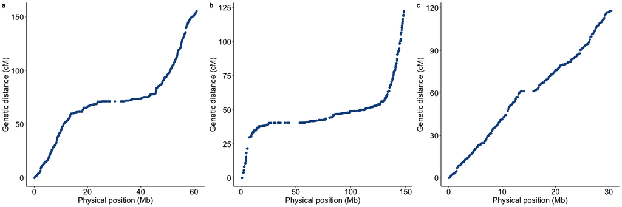

Figure 2.1: Three different Marey maps showing contrasting patterns of recombination. Marey maps are those of *Sorghum bicolor* chromosome 10 (a), *Zea mays* chromosome 10 (b) and *Arabidopsis thaliana* chromosome 1 (c). The genetic distance (cM) is plotted as a function of the physical distance (Mb). Each point is a genetic marker.

The idea is that the observed function between genetic and physical distances is not necessarily linear. A linear function would be the uniform model, where the recombination rate is constant along the chromosome. However, when the genetic distance increases for a constant physical distance, there is locally more recombination than expected under the uniform model (the linkage between loci decreases). Inversely, when the genetic distance tends to decrease, there is less recombination than expected (see the figure below). White and Hill developped a conceptual model of Marey maps making the relation between the curvature of the Marey function and the distribution of the recombination along the chromosome (White and Hill, 2020).

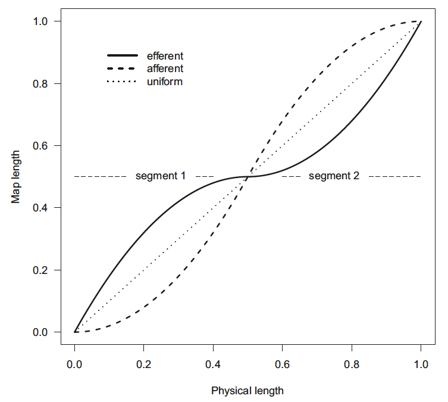

Figure 2.2: Conceptual model of intra-chromosomal recombination heterogeneity proposed by White and Hill (2020). In the uniform model, the recombination rate is constant along the chromosome. Recombination is concentrated in the centre in the afferent model. Recombination is concentrated toward the telomeres in the efferent model.

Now, we can use the empirical Marey map to estimate the local recombination rate along the chromosome. The local recombination rate is simply the derivative of the function in a point, expressed in cM.Mb$^{-1}$. There is only few softwares and packages designed in this purpose (Martin and Bryan, 2016; Siberchicot, Bessy, et al., 2017; Siberchicot, Clément Rezvoy, et al., 2017) and I adopted the same method as in the MareyMap R package (Rezvoy et al., 2007). Besides, I took inspiration in the Mapfuser integrative pipeline to develop my own pipeline of correction/validation of Marey maps (van Muijen et al., 2017).

### Genomic data

All genomic data used to construct Marey maps and estimate recombination landscapes (i.e. genetic map + physical map) come from the literature and published supplementary materials. I am gathering genetic maps in any species of Angiosperms, and even some Gymnosperms as outgroup, with special interests to sex-specific maps (sex-averaged maps are good too), wild/domestic species (if possible in the same genus/family), high variance in genome/chromosome sizes (mainly lacking of large genomes), and finally a large representative phylogeny. I began by searching in the literature for genetic maps, which I found mainly in QTL studies. Typical keywords were ‘genetic maps’, ‘linkage maps’ associated to ‘high-density’, ‘saturated’ to target best quality maps, and finally species names. My main criterion to sort results were species names (species with a well annotated reference genome) and date of publication (first searching the most recent studies for a given species, then going backward in time). In abstracts I searched for a minimum number of markers (> 40 markers per chromosome) to reject low density maps. This rough and naive strategy allowed me to have a broad overview of which species and kind of data are represented in the literature in a short time, at the very beginning of the PhD, yet it lacked specificity and the number of data effectively recovered per amount of time was low. Then, I focused on more specific searches. In reviews or meta-analyses studying recombination among large phylogenetic groups, I looked for references to genetic maps in Angiosperms (Haenel et al., 2018; Stapley et al., 2017). All references were saved with metadata for further analyses (e.g. sex of the map, ploidy level, recombinant inbred lines, chromosome size in Mb and cM, number of markers).

Actually, I am looking to extend my dataset to a larger panel of maps based on specialist knowledge. Besides the still ongoing literature search, I moved to a more active search, with the help of Sylvain Glémin. We prospected the network of researchers he knows working on genetic maps. So far, we have many promising answers (*Vitis vinifera*, *Oryza* sp., *Coffea* sp., *Arachis* sp., *Hevea brasiliensis*). The next step will be to contact authors outside of our close network, especially those that didn’t published their high-density genetic maps in the references I found, and ask them for their data. Once completed, corrected and validated, our Marey maps dataset could contribute to the open database of the MareyMap R package and the associated MareyMap Online website (Rezvoy et al., 2007; Siberchicot, Bessy, et al., 2017; Siberchicot, Clément Rezvoy, et al., 2017). So far, MareyMap contains only two ready-to-use maps of Angiosperms species, *Arabidopsis thaliana* and *Oryza sativa*, and authors of the MareyMap package, Laurent Gueguen and Gabriel Marais, are already interested by this collaboration.

### Marey maps and recombination estimates

In order to process genetic maps for producing recombination maps, genetic dataset were as much as possible automatically processed through correction, filtering, settings calibration and validation procedures for reproducibility purposes. However, given the various non-standard nature of data gathered, a manual curating and formatting of each new dataset was necessary. Hence, automatization of some steps was impossible, especially at the beginning of the pipeline. The Marey method is a graphical method, so figures were systematically produced at each step as a way to evaluate our results. Besides, each procedure of correction/interpolation is registered in log files to keep the history of each map.

During the description of the whole process, I will speak of dataset and maps. A dataset is a reference to the genetic map(s) produced in a study, identified by the species and the reference to its authors. A map concerns data on a single chromosome of a dataset. Hence there is as many maps as there are chromosomes in each dataset, and there can be the same species multiple times, if many published dataset are available. Besides, even if a singular map is not retained (not passing quality tests), other maps of the dataset may pass.

Basically, the data we need in input is marker name, chromosome number, physical distance (bp) and genetic distance (cM). Metadata are also necessary to further processing of the map (e.g. the mapping function used for genetic distances, whether Haldane or Kosambi and the reference genome used for physical positions). Moreover, interpolation methods used to produce recombination maps require some quality criterion. A good genetic map must have at least 40-50 markers per chromosome to produce reliable estimates. Most of markers must follow a monotonous increasing function when plotting genetic distances as a function of physical distances, that is the guarantee that marker order is congruent between the genetic map and the reference genome. Nonetheless, outliers can be easily removed.

1. If map did not have physical positions (only genetic positions published), then physical positions were mapped by blasting markers (either sequence tags or primers) onto the most recent reference genome.
2. Marey maps were plotted for quality control. High quality maps were working out-of-the-box. Medium quality maps needed adjustments in interpolation to deal with noise, gaps and other errors. Low quality maps were rejected.

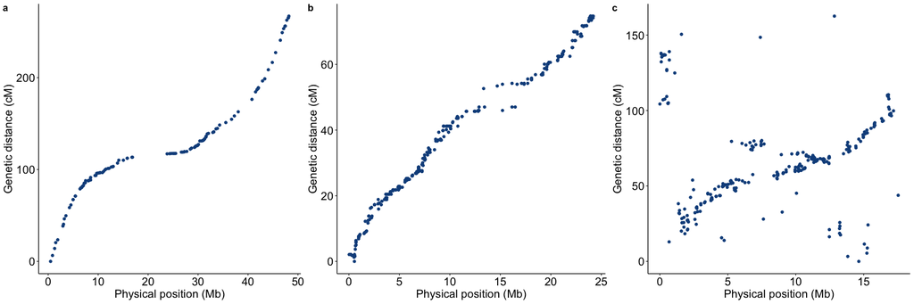

Figure 2.3: Three Marey maps of different quality. The Marey map of *Brachypodium distachyon* chromosome 4 is a high quality map (a). The map of *Vitis vinifera* chromosome 1 is a medium quality map and will require some corrections (b). The *Linum usitatissimum* chromosome 5 map is a low quality map and is immediately rejected (c). The genetic distance (cM) is plotted as a function of the physical distance (Mb). Each point is a genetic marker.

3. The function must be increasing, because genetic and physical positions must be anchored in the same direction. A wrong direction on a whole chromosome was easy to correct, yet sometimes only scaffolds have been anchored in the wrong direction, and correction of these shorter segments must be partly manual (manual zone selection of incorrect segment boundaries). Maps or segments were reoriented by flipping genetic distances in the other direction (physical positions were fixed to be the same as in the reference genome).
4. Departures from a monotonous function denote discrepancies between marker order in genetic and physical maps that are often imputable to problems with assembly or incorrect marker genetic positions (DeWan et al., 2002b). Either the genetic or the physical map contains errors in the longitudinal ordering of markers. These incongruences can have strong effects on the interpolation method, increasing the peakedness of the recombination rate variation along the chromosome. Outliers were removed if they were clearly identified. Otherwise the adjustment of the smoothing function to a stronger smoothing can deal with the noise produced by incongruences while reducing the resolution (estimated landscapes are smoother). Outlier markers were not removed from the map but just flagged as invalid markers, hence they can be incorporated again if necessary. Estimated landscapes were conservative. They had a lower power to detect peaks of recombination than methods based on polymorphism data (i.e. hotspots), yet they had a lower sensitivity to small errors in markers, as we captured broad-scale variations.
5. Finally, to estimate the local recombination rate, a curve was fitted to the Marey map, often through a smoothing function. Maps that passed the step (4) were ready for curve fitting. Curve fitting is the estimation of parameters of a mathematical function adjusted to the scatterplot of markers positions. Recombination rates were the derivatives of this mathematical function (i.e. the fitted curve). Curve fitting methods had to deal with missing data or small discrepancies between genetic and physical positions introducing gaps (e.g. because of gaps in the reference genome). I chose loess regression and smooth spline interpolation, that are methods used in signal processing and known to deal with noisy signals and gaps. However, smoothing functions depend on a smoothing parameter (span for loess regression; spar for smoothing splines). The smoothing parameter must be adjusted to the data to avoid over/underfitting. If the smoothing function is too strong, the signal will be completely flattened and a precious information is lost (underfitting). Otherwise, if the smoothing function is too weak, the noise will be interpreted as a signal and introduce artifacts, peakedness and false informations (overfitting). The local recombination rate was the derivative in a point/window. I used fixed non-overlapping windows in the common scales of 1Mb and 100kb. The Marey map approach does not permit finer scales, although the resolution is sufficient to explore the broad-scale patterns of chromosome architecture, ranging from 14Mb to 829Mb. We are therefore more interested in chromosome architecture than precise point-wise estimations. The influence of the scale on estimates is still to be assessed. A scaled version of the recombination map have also been estimated, with the recombination map segmented in 1,000 bins of equal size, in order to easily compare maps of different sizes. The automatic calibration of the smoothing parameter in interpolations (span/spar) was crucial to avoid under/overfitting and enhanced the quality of estimates. The best fitting span/spar parameter was estimated by a systematic K-fold cross-validation procedure. The search of the best value was done in the range 0.2-0.5 with a step of 0.05. I implemented two common estimators of goodness-of-fit for the K-fold cross-validation: least absolute deviations and least-squares deviations. Finally, I retained the smoothing parameter that most often minimized these criteria among the five K-fold cross-validation replicates. I observed an absolute convergence between both criteria, suggesting a strict consensus on the smoothing parameter for each map. The loess regression was set with the automatically calibrated span parameter, for a polynomial degree of 2 as in (Rezvoy et al., 2007). Negative estimates are not possible as we assume a monotonously increasing function. Consequently, negative values were forced to zero. The smooth splines interpolation was set with the automatically calibrated spar parameter. As for loess regression, negative values were forced to zero. Confidence intervals of recombination rates at 95%, for loess and smooth splines, were computed by 1,000 bootstraps of markers (random resampling of markers). Ultimately, I have prospects on a more robust method of smooth splines, as described in Berloff et al. (2002). It is a smooth splines interpolation with conditions/constraints on the interpolated curve. Interestingly, the curve is forced to be monotonic before estimations of the derivative.

### Filtering estimated recombination landscapes

At this step, the question was what is a good quality reliable recombination map? Was it impacted by errors in genotyping, order of markers in genetic maps and finally interpolation methods? Ultimately, can we trust our estimates? I had to filter the interpolated recombination maps. I used multiple criteria for rejecting incorrect maps, each one being redhibitory. The most simple criteria were the mean and standard deviation (SD) statistics, computed on estimates.

- Biases in mean recombination rates estimates were assessed by comparing the mean of estimates with the average chromosome wide recombination rate, that is simply the total length of the genetic map (cM) divided by the total length of the physical map (Mb). Departures from the linear relationship (Quantile-Quantile line) between mean estimated recombination rates and the average chromosome wide recombination rate was a simple criterion of exclusion for chromosomes showing a biased mean. Maps beyond an arbitrary threshold of ±1 around the linear Q-Q line were rejected. However, a more robust estimator of map quality should be found, whose stringence is not arbitrary and not dependent of the global quality of the dataset.

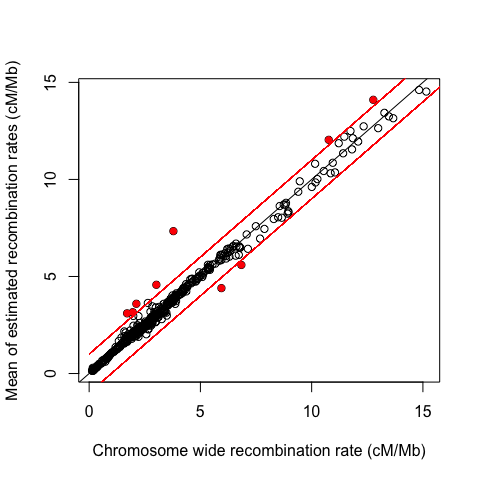

Figure 2.4: Linear relationship between the chromosome wide recombination rate (total genetic length divided by total physical length, cM/Mb) and the mean of recombination rates estimated in 100kb along the chromosome (cM/Mb) used as a cross-validation procedure. Each point represent a chromosome map. Red lines are the rejection interval of maps with a biased mean (±1). Red dots are rejected maps.

```
## Number of maps rejected for the biased mean criterion: 9
```

- Biases in standard deviation (SD) of recombination rates estimates were assessed directly on the empirical distribution of SD. I considered that biased SD would show a significant departure from the empirical distribution of SD. As we can observe a nearly Gaussian distribution ranging from 0 to 7, every map with a SD above 7 was rejected.

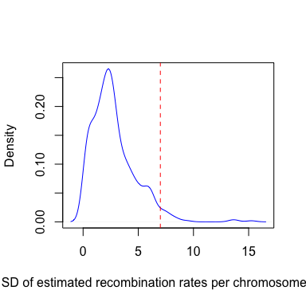

```
## Summary of the recombination rate SD empirical distribution:
```

```
##    Min. 1st Qu.  Median    Mean 3rd Qu.    Max.
##  0.1947  1.4317  2.3803  2.7864  3.7006 15.2453
```

```
## Number of maps rejected for the biased SD criterion: 16
```

- Overfitting is a more subtle bias to assess. It typically produces artifacts and peakedness that aren’t easy to disentangle from a true signal. The recombination rate will oscillate at high frequencies, close to or well under the sampling frequency (i.e. 100kb and 1Mb) and local maxima will attain very high values. For now, overfitting artifacts are graphically assessed. However, the process could be automatized based on signal processing R packages for frequency detection, such as forecast or BaSAR (Granqvist et al., 2012; Hyndman and Khandakar, 2008). Automatic calibration sometimes fails to optimize the smoothing parameter. The solution to overfitting is often to increase the smoothing span, although it may greatly reduce the resolution of the estimated landscape and underestimate the recombination rate heterogeneity (Gaut et al., 2007). Maps flagged with overfitting were re-estimated with a larger span parameter, and tested again. This feedback loop allowed a better settings control and enhanced robustness to noise in data, despite a loss of resolution. If the re-estimated map didn’t improved, I removed the entire map. However, it could be interesting to mask only regions presenting errors and to propagate informations about those masked regions to further analyses. Hence we could keep a significant amount of data, although some maps remained incomplete (Bauer et al., 2013). Besides, a Bayesian approach, considering uncertainties in data and the interpolation process could greatly benefit to the accuracy of the recombination landscape (Petit et al., 2017).

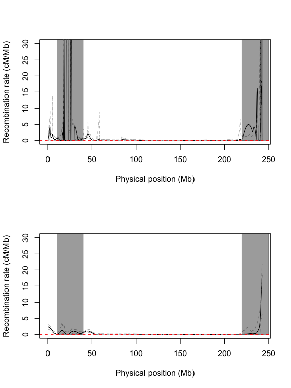

Figure 2.6: Recombination landscape of *Cenchrus americanus* chromosome 2 experiencing overfitting before correction (top) and after correction (bottom) in the regions 10-40Mb and 220-250Mb (regions masked in grey). Estimates were obtained in windows of 100kb with loess regression and a span parameter of 0.1 (overfitting) and 0.2 (corrected).

Finally, the number of rejected maps was:

[output not shown]

[output not shown]

Our pipeline involved many steps of correction/validation. The rigorous examination of every map could be made by hand by experts in mono-specific studies, although the volume of data collected here did not allow this. Automation and reproducibility of processes was inevitable. It was possible to correct errors in rejected maps and to improve our estimates from lessons learned during validation and correction steps and the method may improve in the next months. Feedback loops between validation and interpolation processes increased the quality of our dataset with time.

### Power and sensitivity analysis

Complementary to our correction and validation procedure, a power and sensitivity analysis of the method would be crucial to evaluate the accuracy of our estimates. I won’t expand much on this question, although it should be a huge piece of work for the next months. A complete framework of power and sensitivity analyses would require simulations of large genetic sequences (whole chromosomes) of known recombination map, for a large amount of individuals of known pedigree. So far, I found no model for simulating genetic maps directly from a known recombination landscape, although simulation of chromosome sequence of known recombination is possible in SLiM (Haller and Messer, 2019, 2019). We could assess the reliability and sensitivity of the Marey map method with the SLiM software. However, we would have to use a mapping function and a genetic mapping algorithm to generate the genetic map from the chromosome sequence and it would be difficult to disentangle effects of genetic mapping from Marey map interpolation methods. At this time, I found no software able to generate directly a genetic map from known recombination map and physical distances. My second option to evaluate sensitivity could be to apply transformations (e.g. missing data, gaps, jittering on markers positions) on maps considered as highly reliable and compare the outputs for the original and transformed maps. Although this kind of analyses may require a substantial amount of time, I believe it is important to evaluate the uncertainty of our estimates with the most rigorous methods.

# 3 Results

### Summary statistics

```
## There are 39 fully validated dataset.
```

```
## In which there are 35 different species:
```

```
##  [1] "Aegilops speltoides"     "Arabidopsis thaliana"
##  [3] "Arachis duranensis"      "Brachypodium distachyon"
##  [5] "Brassica napus"          "Capsicum annuum"
##  [7] "Cenchrus americanus"     "Citrullus lanatus"
##  [9] "Coffea canephora"        "Cucumis melo"
## [11] "Cucumis sativus"         "Glycine max"
## [13] "Gossypium hirsutum"      "Gossypium raimondii"
## [15] "Hordeum vulgare"         "Lupinus angustifolius"
## [17] "Malus domestica"         "Manihot esculenta"
## [19] "Oryza sativa"            "Panicum hallii"
## [21] "Phaseolus vulgaris"      "Populus deltoides"
## [23] "Populus simonii"         "Prunus mume"
## [25] "Sesamum indicum"         "Setaria italica"
## [27] "Solanum lycopersicum"    "Solanum tuberosum"
## [29] "Sorghum bicolor"         "Theobroma cacao"
## [31] "Triticum aestivum"       "Triticum dicoccoides"
## [33] "Triticum urartu"         "Vitis vinifera"
## [35] "Zea mays"
```

```
## Which represent 477 chromosomes.
```

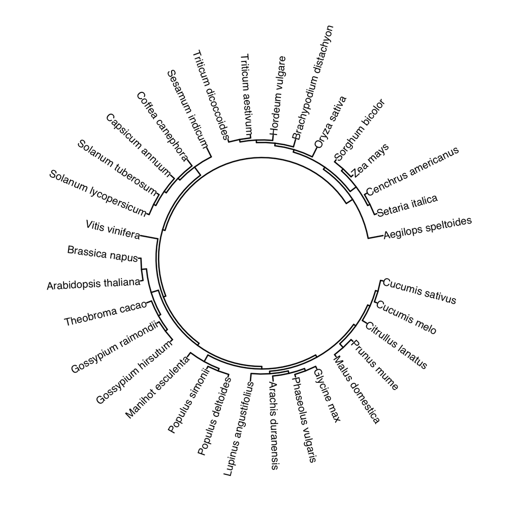

Figure 3.1: Phylogenetic view of the advancement of the project, showing available data across all plants (phylogenetic tree constructed with Tree of Life data). Only species with a validated recombination landscape are showed.

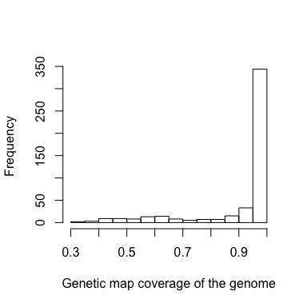

Figure 3.2: Distribution of genetic map coverage in the dataset.

```
## Proportion of maps with a genetic coverage over 95% was 0.72
```

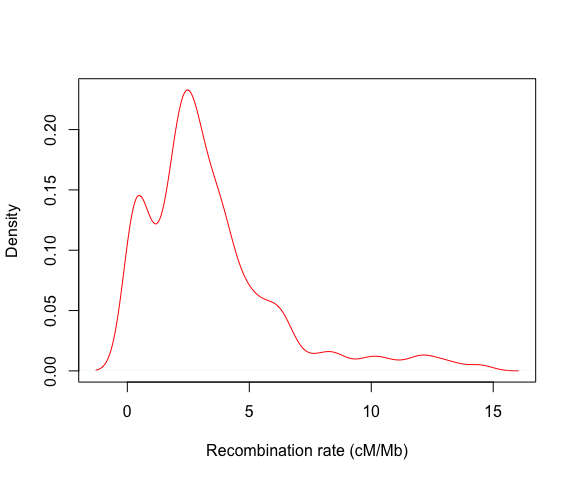

Figure 3.3: Distribution of chromosomes’ recombination rates (cM/Mb) amongst all species in the dataset.

In preliminary observations, we observed a negative correlation as expected between chromosome size and the mean estimated recombination rate.

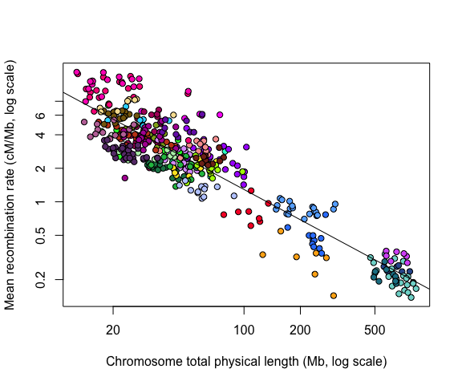

Figure 3.4: Correlation between the chromosome size (Mb, log scale) and the average recombination rate (cM/Mb, log scale) estimated with loess regression in windows of 100kb. Each point represents a chromosome. Species in different colors.

```
##
##  Spearman's rank correlation rho
##
## data:  chromosome.stats$phys.map.length and chromosome.stats$mean.recrate
## S = 32722002, p-value < 2.2e-16
## alternative hypothesis: true rho is not equal to 0
## sample estimates:
##        rho
## -0.8089972
```

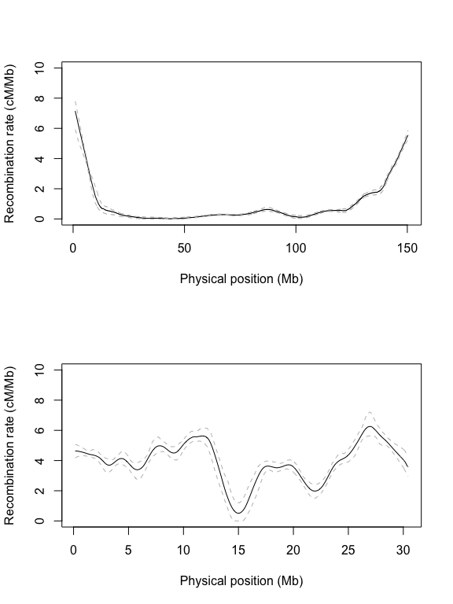

Figure 3.5: Recombination landscapes of *Zea mays* chromosome 10 (top) and *Arabidopsis thaliana* chromosome 1 (bottom). Estimates were obtained in windows of 100kb with loess regression and automatic span calibration. Confidence interval at 95% (grey dashed lines) estimated by 1,000 bootstraps.

# 4 Axis one. Recombination is not randomly distributed in the genome

### Landscape structure

We hypothesized that the distribution of the recombination is not random (i.e. non uniform) and that recombination rates show heterogeneity. The question was, how to represent this structure to make comparisons between chromosomes and species?

One way I found to resolve this question was the broken stick model. The broken stick is well known in community ecology for distributions of species abundance and the niche appointment model (MacArthur, 1957). In the ecological definition of the model, a stick is decomposed in segments whom sizes represent the relative abundance of each species. A community with equally abundant species show segments of same size, while a community with a dominant species show a large segment with many other small segments. recently, White and Hill also proposed to describe recombination landscapes by a broken stick model (White and Hill, 2020). They argued that decomposition in three segments seemed sufficient to describe the broad-scale variation observed in recombination landscapes.

The broken stick model I implemented was applied directly to the Marey map, and not to the estimated landscape. Each vertical bar display the $k$ proportions for each chromosome/species, $k$ being the number of segments. The Marey map is decomposed in three segments of equal genetic distance ($1/k$ fo the total genetic distance). For each segment, the corresponding relative physical distance is retrieved. Under a uniform distribution of recombination, we expect the relative physical distance to be similar to the relative genetic distance in the $k$ segments. Relative physical distances lower than $1/k$ reveal high recombination rates. Relative physical distances higher than $1/k$ reveal low recombination rates. Thus, we were able to visualize and even test theoretical expectations of uniform or concentrated structures, as well as symmetry or asymmetry in the recombination landscape.

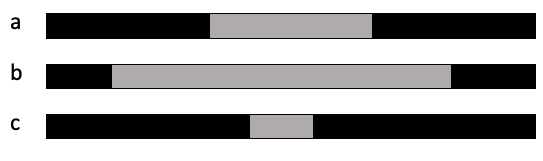

Figure 4.1: Theoretical distributions of recombination under the broken stick model for k=3. The physical map is segmented in three segments of equal genetic size. The size of a segment is the relative physical length (physical length of the segment divided by the total physical length of the chromosome). (a) The distribution is uniform across the chromosome with three segments of equal physical size (relative physical size = 1/k). (b) The distribution is concentrated in telomeres, with a longer central segment. (c) The distribution is concentrated away from telomeres, with a shorter central segment.

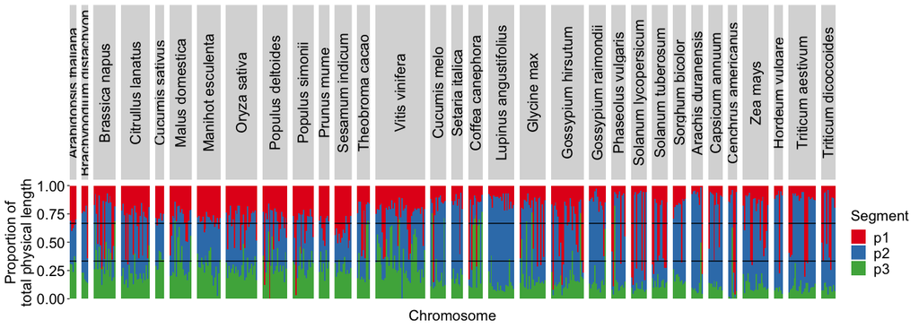

Figure 4.2: Global structure of recombination heterogeneity across the chromosome for k=3. Each map (i.e. chromosome) is vertical. Segments sizes are the relative physical size in k segments equally distributed along the genetic distances. Segments p1 and p3 are the tips of the chromosome (first and last third of the genetic map), while p2 is the centre of the chromosome. Horizontal black lines are theoretical expectations for segment size of 1/3 and 2/3.

In empirical Marey maps with $k$=3, we expected a variation between the (a) and (b) patterns. It seemed to work for most maps, that were congruent with the broken stick, although there were strange behaviors in some maps, with extremely long tips (see Maize for example). Indeed, k=3 was not sufficient to describe our data. These artifacts may be caused by a segment cutting frequency (the $k$ parameter) too low for the observed process. Information theory predicts artifacts (or aliases) if the sampling frequency is not at least twice the frequency observed in the studied process, i.e. the Nyquist criterion (Shannon, n.d.). Hence we can expect a clearer signal by increasing the number of segments of identical genetic distance to $k$=10, given the observation that most patterns are decomposed in at least three phases.

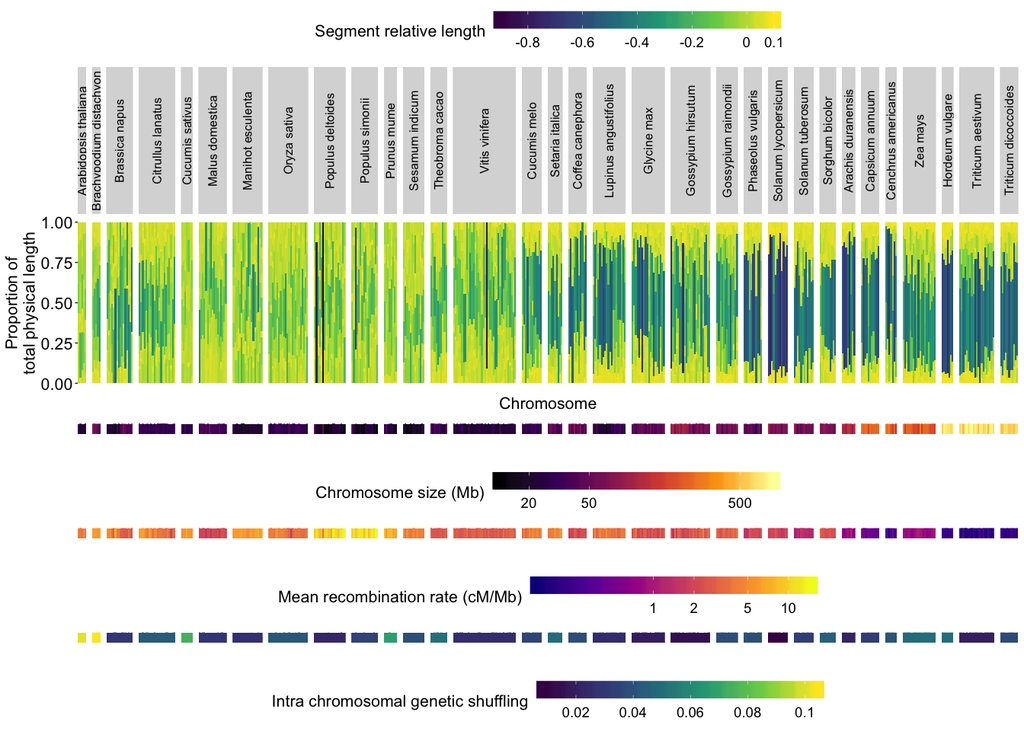

Figure 4.3: Global structure of recombination heterogeneity across the chromosome for k=10. Each map (i.e. chromosome) is vertical. Segments sizes are the relative physical size in k segments equally distributed along the genetic distances. Segment color is a gradient expressing the difference between the expected relative distance size (1/k) and the observed relative physical size. Negative values (darker colors) imply segments longer than expected, hence a lower recombination rate. Below is represented in colors the chromosome size (Mb), the mean recombination rate of the chromosome (cM/Mb) and the intrachromosomal genetic shuffling rate as defined in Veller et al. (2019).

The segmentation of the Marey map in k=10 segments showed a clearer patterns. To enhance the visualization of the information of segment physical size, I used a color gradient. Segment color was a function of the difference between the expected relative physical size (1/k) and the observed relative physical size (expected - observed). Negative values (darker colors) implied segments longer than expected, hence a lower recombination rate. We can really distinguish two groups of recombination landscapes, with homogenous distribution of recombination in *Arabidopsis thaliana* or *Malus domestica* for example, while species like *Solanum lycopersicum* or *Capsicum annuum* revealed a strongly structured pattern, with a large region of low recombination in the middle of the chromosome and high recombination rates in the telomeres.

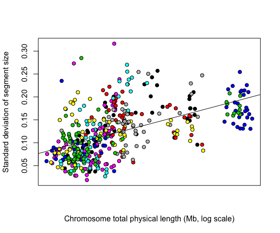

Figure 4.4: Correlation between the chromosome size (Mb, log scale) and the heterogeneity of segment sizes under the brocken stick model (standard deviation). Each point represents a chromosome. Species in different colors.

```r
# Correlation of segment heterogeneity (standard deviation) and chromosome size
# (Mb)
cor.test(brockenstick$sd, brockenstick$chr_size, method = "spearman")
```

```
##
##  Spearman's rank correlation rho
##
## data:  brockenstick$sd and brockenstick$chr_size
## S = 6573504, p-value < 2.2e-16
## alternative hypothesis: true rho is not equal to 0
## sample estimates:
##       rho
## 0.5867607
```

```r
# Correlation is significantly positive, higher heterogeneity in segment size
# (i.e. recombination rates) is linked to larger chromosomes
```

After describing the observed structure, I would like to pursue by inferring the underlying structure with statistical methods. The broken stick model is suitable for statistical testing (Fattorini, 2005; Smart, 1976). Besides, there is more to do to study the segmentation of the recombination landscape, by inferring segments boundaries instead of taking a constant size of 1/$k$. Bernaola-Galvan et al. (2004) used an algorithmic method of entropic compositional segmentation to cut DNA sequences in blocks maximizing the GC contrast between them. That is the kind of method that could be applied to decompose the structure of recombination landscapes in blocks maximizing recombination contrasts and infer the underlying structure of the landscape in a more statistical way.

### Autocorrelation

Autocorrelation is a measure of the structure existing in data and could be one more useful summary statistic to describe recombination landscapes. There is lot of evidences of autocorrelation in genomic data (Bernaola-Galván et al., 2002; Cai et al., 2017; Carpena et al., 2007). Indeed, base composition is heterogenous and far from stationarity (Duret and Arndt, 2008). Our hypothesis is that the distribution of recombination along the chromosome is autocorrelated. Although, recombination rate architecture may vary between species from clusters in telomeres in species with high heterogeneity to diffuse architecture in others. Moreover, stationarity is not ensured within recombination landscapes. In such a context, genomic data along the chromosome can be interpreted as longitudinal time series, with similar statistical frameworks (Chakravarthy et al., 2004).

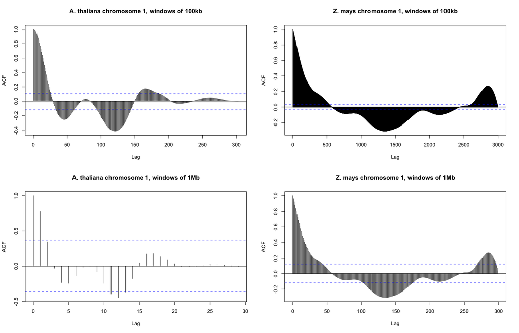

Figure 4.5: Autocorrelation function of the recombination landscape of *Arabidopsis thaliana* (left) and *Zea mays* (right) chromosome 1 at windows size of 100kb (top) and 1Mb (bottom).

The autocorrelation function is congruent at both scales (1Mb and 100kb), and the lag of autocorrelation is large, suggesting large clusters of recombination or long distance interferences in the recombination process. At broad-scale, recombination seems distributed in large blocks of similar recombination rate rather than a diffuse structure of many small regions of high recombination. Consequences of autocorrelation are important in further data analysis, with violation of assumptions, incorrect inferences and misleading results (Hahn, 2006) and autocorrelation must be taken in account, although it ultimately depends on the genomic scale considered (Bernaola-Galván et al., 2002; Carpena et al., 2007; Chakravarthy et al., 2004).

### A probabilistic view of recombination landscapes

The idea was to reduce the global pattern to a reduced set of parameters that summarized well the global distribution of recombination along the chromosome (Li and Freudenberg, 2009). Moreover, a theoretical model for the distribution of recombination, even phenomenological, could provide useful predictions to test on data. Our model was in agreement with the conceptual model of Haenel et al. (2018), where it was suggested that recombination is high in fixed regions at telomeres, separated by a region of low recombination varying with the length of the chromosome.

Avec X ~ Gamma1(alpha1, beta1) et X’ ~ Gamma2(alpha2, beta2).

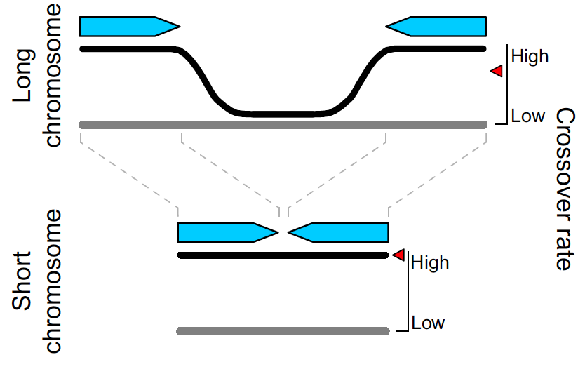

One advantage to use a model is the test of theoretical predictions. Hence, we can discuss the influence of the chromosome size L, the asymmetry p or the shape of the Gamma distribution to the recombination landscape. Indeed, we can observe that for the same Gamma distributions, the change of only the chromosome size L could lead to the same variation of global shapes we observed (figure below, at center).

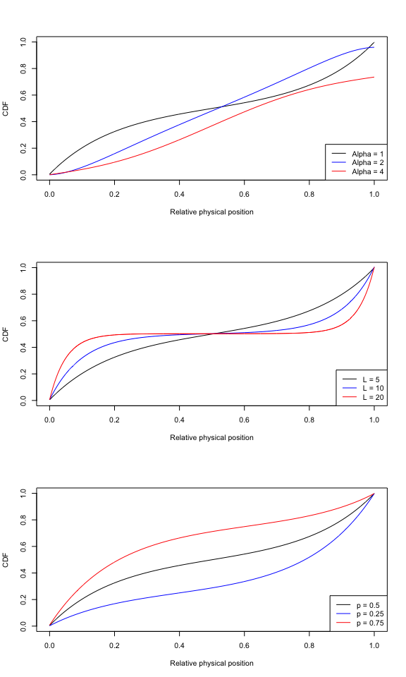

Now that my probabilistic model seems to work with observed patterns, I can consider the fitting of the Gamma Telomere CDF to our empirical Marey maps and the estimating of the goodness-of-fit and parameters. Furthermore, parameters of the probability distribution can be taken into account as statistics summarizing the global pattern.

### Recombination heterogeneity varies among chromosomes/species?

Recombination is heterogenously distributed along chromosomes, yet some patterns seems consistent among at the inter-chromosomal and inter-specific levels. A more integrative view of the evolution of recombination across Angiosperms should be strengthened by a large number of species considered, with a large phylogenetic range. So far, with 28 species, each one having 5 to 21 chromosomes, our dataset is quite consequent, and I expect to increase further the number of species, with phylogenetic species of interest (e.g. *Amborella trichopoda* as a basal species in Angiosperms). Thus, the variation of recombination across chromosomes ans species could be investigated with phylogenetic analyses. If recombination landscapes are species specific, as it is suspected, the variance between species must be much higher than the variance between chromosomes once controlled for the phylogeny.

Moreover, phylogeny might not be the only one factor explaining the heterogeneity in recombination landscapes. The last part in the description of the non-random distribution of the recombination will be to make a statistical classification of observed landscapes to see if there is common patterns shared by a group of species. Only then factors shaping recombination landscapes might be identified and further explored. Yet, this part is still prospective and multivariate analyses (e.g. discriminant analyses, hierarchical clustering or even machine learning classification) seems appropriate tools.

# 5 Axis two. Recombination structure is correlated to genome architecture

### Longer chromosomes have a lower mean recombination rate, but are they less variable?

Given that at least one recombination event is mandatory at each segregation but that there is few evidences of numerous double-strand breaks in a single meiosis, we can expect that shorter chromosomes will experience much higher recombination rates than longer chromosomes. Such a correlation has already been investigated in previous meta-analyses, although on fewer Angiosperm species (Haenel et al., 2018; Stapley et al., 2017; Tiley and Burleigh, 2015). That is exactly what we observed in the relationship between the mean of the recombination rates and the chromosome size, both in Mb and pg (C-values).

However, the high diversity in chromosome sizes and recombination rates suggest an underlying relationship between heterogeneity in recombination rates and chromosome size. The use of recombination landscapes with variation in recombination rates along the chromosome allows a more detailed approach than the per chromosome Genome Wide Recombination Rate previously used (GWRR, the total genetic length divided by the total physical length). Now we can estimate the heterogeneity of the recombination rate in a chromosome by the standard deviation.

However, large variations in the mean recombination rate among species (ranging from 0.14 to 8.36 cM.Mb$^{-1}$) may greatly influence the relationship between the recombination variance and the chromosome size. When the standard deviation was divided by the mean recombination rate to take into consideration the variation of recombination rates between chromosomes, the correlation was significantly positive (Spearman’s correlation test). The namely coefficient of variation (CV, the ratio sd/mean) is a standardized measure of dispersion.

```
##
##  Spearman's rank correlation rho
##
## data:  chromosome.stats$phys.map.length and CV
## S = 6335104, p-value < 2.2e-16
## alternative hypothesis: true rho is not equal to 0
## sample estimates:
##       rho
## 0.6497713
```

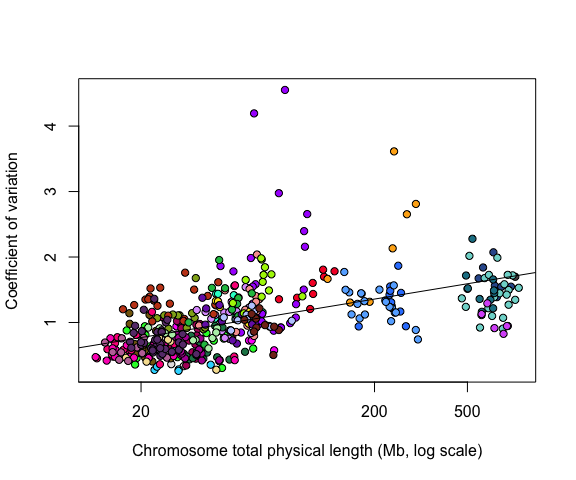

Figure 5.1: Correlation between the chromosome size (Mb, log scale) and the coefficient of variation (standard deviation/mean) estimated with loess regression in windows of 100kb. Each point represents a chromosome. Species in different colors.

Independently of the large variations in mean recombination rates between chromosomes, larger chromosomes had a higher intra-chromosomal heterogeneity than smaller ones.

### Is recombination acting away from the centromere?

Two very interesting hypotheses are that recombination is concentrated away from centromeres and that centromere position shapes the global recombination landscape. If the centromere is acting as a suppressor of the recombination, centromeric regions should coincide with regions of low/null recombination. Besides, if there is a negative interference between the centromere and the recombination process, we should observe a decrease in the recombination rate when the distance to the telomere increases.

The comparison of both distributions of recombination rates, either as a function of centromere or telomeres, should help to disentangle between these two competing hypotheses. Besides, modeling both hypotheses with a phenomenological model (see above) might be a prerequisite to infer the best underlying model within a statistical framework (e.g. Approximate Bayesian Computation).

The position of the centromere is not necessarily in the center of the chromosome, and architecture of centromere locations is very variable (Levan et al., 2009). A database of centromere locations is necessary to answer our questions. The position of the centromere is accessible in the literature for most species.

### Gene density

In organisms without PRDM9 driving the hotspot distribution, recombination is majoritarily occuring in gene promoters or 5’ end at the beginning of genes. Hence, recombination rates should be positively correlated to gene densities. I used directly the number of genes in statistical analyses instead of the gene density. The gene density is simply the number of genes divided by the size of the window (100kb and 1Mb). A gene was considered in a window if the start coordinates fell inside the window boundaries.

I explored the correlations between gene density and the local recombination rate. I just fitted a linear model for preliminary exploration of the relationship between gene count and recombination, although residuals are departing from gaussian assumption. However, GLMs did not performed better on data. I tested the significance and strength of the correlation with a Spearman’s test.

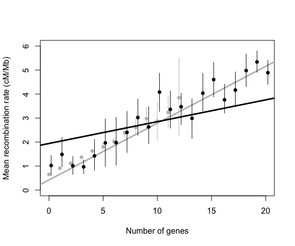

Figure 5.2: Mean recombination rate as a function of the number of genes in windows of 100kb for *Zea mays* (grey) and *Arabidopsis thaliana* (black), all chromosomes pooled, with a confidence interval at 95% (1,000 bootstraps). Regression line estimated by a linear model directly on data.

The correlation was significant for maize and *A. thaliana*, but the slope of the linear relationship was higher for maize. Thus, the recombination landscapes were completely different between maize and *A. thaliana*, although the distribution of gene count was decreasing with the distance to telomeres for both species. Recombination is concentrated in the telomeres in maize while fluctuating around a nearly constant mean in *A. thaliana* , and it may implies different mechanisms. The correlation between recombination and gene density was also significantly positive in *Brachypodium distachyon*, *Triticum aestivum*, *Malus domestica*, *Cucumis sativus* and *Sorghum bicolor*.

```
## Correlation for Zea mays:
```

```
##
##  Spearman's rank correlation rho
##
## data:  genecount_map$rec.rate and genecount_map$gene_count
## S = 8.1685e+11, p-value < 2.2e-16
## alternative hypothesis: true rho is not equal to 0
## sample estimates:
##       rho
## 0.4702506
```

```
## Correlation for Arabidopsis thaliana:
```

```
##
##  Spearman's rank correlation rho
##
## data:  genecount_map$rec.rate and genecount_map$gene_count
## S = 203519106, p-value < 2.2e-16
## alternative hypothesis: true rho is not equal to 0
## sample estimates:
##       rho
## 0.2717048
```

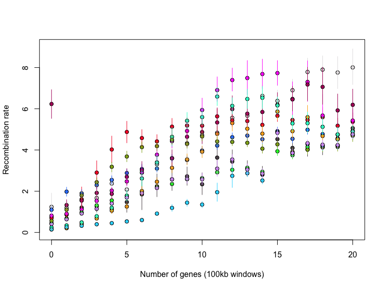

Figure 5.3: Mean recombination rate as a function of the number of genes in windows of 100kb, all chromosomes pooled, with a confidence interval at 95% (1,000 bootstraps). 12 species plotted in different colors. Maximum number of genes limited to 20.

Recombination tends to increase the genetic reshuffling and create random combinations of markers from the two parents to the progeny (Veller et al., 2019). Implications of the positive correlation between recombination rates and gene density are that recombination tends to homogenize the gene shuffling. It means that recombination should be more homogeneously distributed according to gene distribution than physical distances. Indeed, we can change the Marey maps to represent the genetic distance (cM) as a function of gene distance (cumulative number of genes) rather than physical distances in Mb.

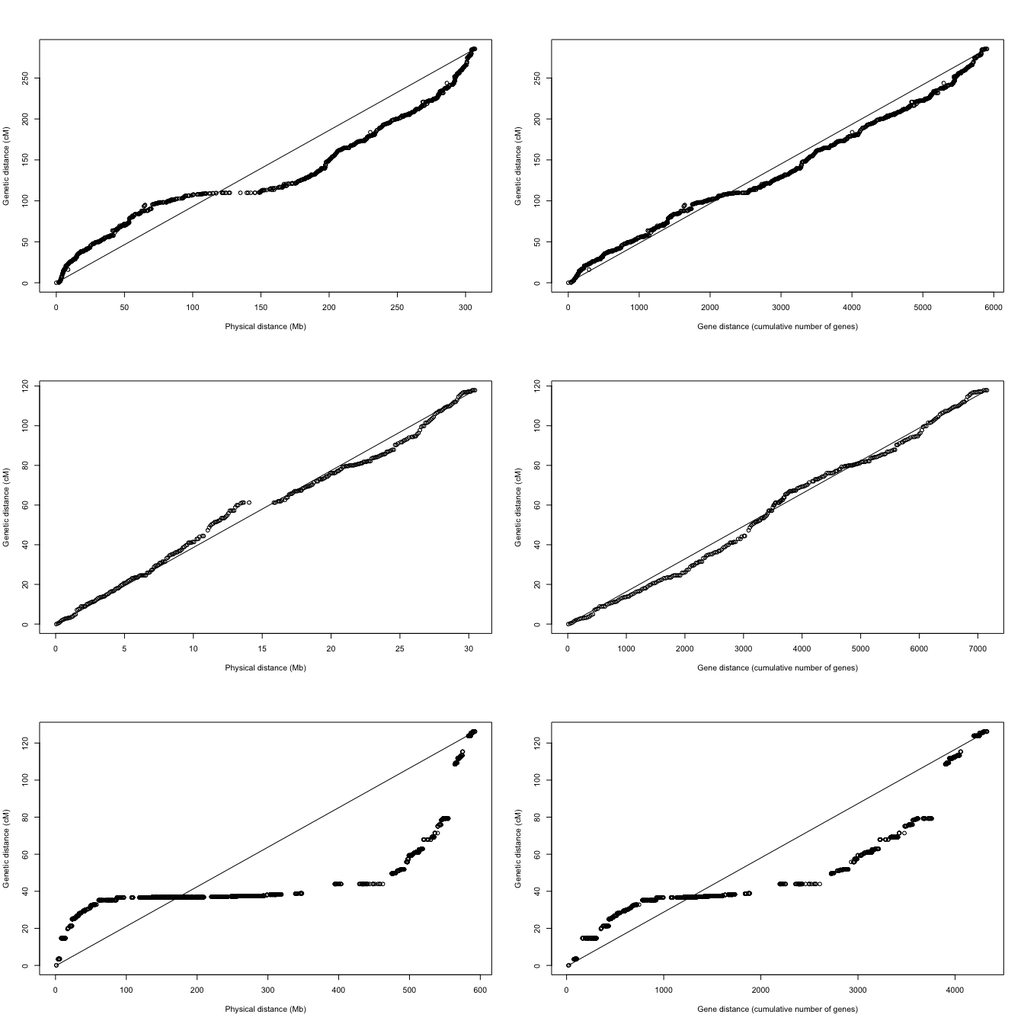

Figure 5.4: Genetic distances as a function of the physical distance in Mb (left) or the gene distance (cumulative number of genes; right) for *Zea mays* chromosome 1 (top), *Arabidopsis thaliana* chromosome 1 (center) and *Triticum aestivum* chromosome 1A (bottom). The solid line represents a linear relationship between both axes.

# 6 Axis three. Recombination structure is correlated to genomic features

### Correlations between the GC content and the local recombination rate

The recombination mechanism has molecular consequences on nucleotide composition. The recombination is known to be mutagenic, even if effects can be relatively small. Besides, repair mechanisms of DNA strand breaks induce a biased genic conversion toward GC (gBGC) similar to selection toward GC bases, contributing to a GC increase at the location of recombination events (Duret and Galtier, 2009; Webster and Hurst, 2012). Thus, in regions of higher recombination rates we must look for an increase of the local GC content, especially in synonymous mutations. As the third position in codons is most often degenerated (i.e. a mutation in the third codon does not change the aminoacid during translation), the GC3 content is assumed to be neutral (i.e. not under selection). Along the chromosome, high recombination regions must reveal a higher GC3 content than low recombination regions through the effects of the gBGC. I am currently supervising Leo Salema, a first year Master’s degree intern for two months, who will assess this crucial hypothesis for the evolution of genome base composition.

His work on the broad-scale genomic landscapes and the correlation between GC and recombination will be completed by the study of fine-scale recombination landscapes estimated on polymorphism data. The inference of fine-scale recombination rates and hotspots of recombination with LDhat and LDhot is expected to confirm broad-scale correlations but also to provide novel insights at the genic level (Fearnhead, 2006; Fearnhead and Donnelly, 2001; Fearnhead and Smith, 2005; Stumpf and McVean, 2003). For example, gradients of recombination within genes could reveal new evidences on the effect of recombination on the evolution of nucleotide composition (Serres-Giardi et al., 2012). Indeed, in *Arabidopsis thaliana*, recombination is concentrated in small regions (few kb) and its effects might be extremely local (Drouaud et al., 2013).

# 7 Conclusions

We confirmed some hypotheses with significant correlations and graphical relationships in species by species investigations, hence reproducing evidences gathered in previous studies. Still, as our design is to assess such relationships across Angiosperms, a lot of work remains to represent the variations and global patterns among chromosomes and species, and ultimately correlations may vary greatly between species. Actually, my main global thinking is how to reduce the large amount of data across Angiosperms in a way that is easy to visualize and test. The broken stick structure barplot I produced above and the computation of relevant summary statistics (e.g. coefficient of variation) are designed in this purpose. Furthermore, multivariate analyses (e.g. discriminant analysis of principal component, hierarchical clustering) are promising developments. Clustering should reveal if there is congruence in recombination landscapes with the phylogeny or some other factors. Ultimately this work could be the matter of two publications. The first one will complement the open MareyMap database with new Marey maps and recombination landscapes in Angiosperms, a taxon which is largely underrepresented despite its high ecological and encomical importance. Besides, our results might be presented in an article. Indeed, our results offer a more detailed description of recombination landscapes and its consequences on genome evolution.

Furthermore, our approach provides novel data to test for genomic correlations with recombination. Although we are fundamentally restricted to global patterns. The large-scale resolution of our estimates (100kb to 1Mb) limits us to correlations in large windows. However, gene or exon scales are highly relevant with many hypotheses that we cannot take in account directly. Estimates of recombination rates and hotspots at the kb scale based on linkage disequilibrium in polymorphism data would be the most important development to assess the recombination landscape and genome evolution at every scale of the genome (Fearnhead, 2006; Hellsten et al., 2013; Stumpf and McVean, 2003). The hypothesis that recombination is driving the gBGC will be tested on Linkage Disequilibrium maps. Besides, the local variations in GC and recombination structure in genic regions will be assessed.

Finally, recombination have implications on the genetic diversity due to the effects of linked selection, either positive (selective sweeps) or negative (background selection) (Wang and Copenhaver, 2018). Nucleotide diversity is often positively correlated to recombination rates (Cutter and Moses, 2011; Roselius et al., 2005), and the importance of recombination in populations has already been assessed (Burri et al., 2015). We still have to investigate if the recombination increases the genetic diversity and selection efficacy in Angiosperms. With a population genomic approach, we could study the effects of recombination on polymorphism, for example between wild and domesticated species (Flowers et al., 2012). Besides, the impact of the domestication process on recombination is a growing field (Dreissig et al., 2019; Ross-Ibarra, 2004; Shen et al., 2019) and I may have collaborations coming on this particular question (ANR DomiSol leaded by Maud Tenaillon). Ultimately, I will make the experience of developping a model to infer the gBGC and the strength of the selection in the genome from polymorphism data.

# References

Adrion, J.R., Galloway, J.G., Kern, A.D., 2019. Inferring the landscape of recombination using recurrent neural networks (Preprint). Evolutionary Biology.

Apuli, R.-P., Bernhardsson, C., Schiffthaler, B., Robinson, K.M., Jansson, S., Street, N.R., Ingvarsson, P.K., 2019. Constructing a high-density linkage map to infer the genomic landscape of recombination rate variation in European Aspen *(**Populus* *Tremula)* (Preprint). Evolutionary Biology.

Apuli, R.-P., Bernhardsson, C., Schiffthaler, B., Robinson, K.M., Jansson, S., Street, N.R., Ingvarsson, P.K., 2020. Inferring the Genomic Landscape of Recombination Rate Variation in European Aspen ( *Populus* *Tremula* ). G3&amp;#58; Genes|Genomes|Genetics 10, 299–309.

Auton, A., McVean, G., 2007. Recombination rate estimation in the presence of hotspots. Genome Research 17, 1219–1227.

Auton, A., Rui Li, Y., Kidd, J., Oliveira, K., Nadel, J., Holloway, J.K., Hayward, J.J., Cohen, P.E., Greally, J.M., Wang, J., Bustamante, C.D., Boyko, A.R., 2013. Genetic Recombination Is Targeted towards Gene Promoter Regions in Dogs. PLoS Genetics 9, e1003984.

Axelsson, E., Webster, M.T., Ratnakumar, A., The LUPA Consortium, Ponting, C.P., Lindblad-Toh, K., 2012. Death of PRDM9 coincides with stabilization of the recombination landscape in the dog genome. Genome Research 22, 51–63.

Backstrom, N., Forstmeier, W., Schielzeth, H., Mellenius, H., Nam, K., Bolund, E., Webster, M.T., Ost, T., Schneider, M., Kempenaers, B., Ellegren, H., 2010. The recombination landscape of the zebra finch Taeniopygia guttata genome. Genome Research 20, 485–495.

Baker, Z., Schumer, M., Haba, Y., Bashkirova, L., Holland, C., Rosenthal, G.G., Przeworski, M., 2017. Repeated losses of PRDM9-directed recombination despite the conservation of PRDM9 across vertebrates. eLife 6, e24133.

Baudat, F., Imai, Y., de Massy, B., 2013. Meiotic recombination in mammals: Localization and regulation. Nature Reviews Genetics 14, 794–806.

Bauer, E., Falque, M., Walter, H., Bauland, C., Camisan, C., Campo, L., Meyer, N., Ranc, N., Rincent, R., Schipprack, W., Altmann, T., Flament, P., Melchinger, A.E., Menz, M., Moreno-González, J., Ouzunova, M., Revilla, P., Charcosset, A., Martin, O.C., Schön, C.-C., 2013. Intraspecific variation of recombination rate in maize. Genome Biology 14, R103.

Berloff, N., Perola, M., Lange, K., 2002. Spline Methods for the Comparison of Physical and Genetic Maps. Journal of Computational Biology 9, 465–475.

Bernaola-Galván, P., Carpena, P., Román-Roldán, R., Oliver, J., 2002. Study of statistical correlations in DNA sequences. Gene 300, 105–115.

Bernaola-Galván, P., Oliver, J.L., Carpena, P., Clay, O., Bernardi, G., 2004. Quantifying intrachromosomal GC heterogeneity in prokaryotic genomes. Gene 333, 121–133.

Blackmon, H., Justison, J., Mayrose, I., Goldberg, E.E., 2019. Meiotic drive shapes rates of karyotype evolution in mammals. Evolution 73, 511–523.

Burri, R., Nater, A., Kawakami, T., Mugal, C.F., Olason, P.I., Smeds, L., Suh, A., Dutoit, L., Bureš, S., Garamszegi, L.Z., Hogner, S., Moreno, J., Qvarnström, A., Ružić, M., Sæther, S.-A., Sætre, G.-P., Török, J., Ellegren, H., 2015. Linked selection and recombination rate variation drive the evolution of the genomic landscape of differentiation across the speciation continuum of *Ficedula* flycatchers. Genome Research 25, 1656–1665.

Cai, L., Li, Q., Du, Y., Yun, J., Xie, Y., DeBerardinis, R.J., Xiao, G., 2017. Genomic regression analysis of coordinated expression. Nature Communications 8, 2187.

Carpena, P., Bernaola-Galván, P., Coronado, A.V., Hackenberg, M., Oliver, J.L., 2007. Identifying characteristic scales in the human genome. Physical Review E 75, 032903.

Chakravarthy, N., Spanias, A., Iasemidis, L.D., Tsakalis, K., 2004. Autoregressive Modeling and Feature Analysis of DNA Sequences. EURASIP Journal on Advances in Signal Processing 2004, 952689.

Chakravarti, A., 1991. A graphical representation of genetic and physical maps: The Marey map. Genomics 11, 219–222.

Charlesworth, D., 2017. Evolution of recombination rates between sex chromosomes. Philosophical Transactions of the Royal Society B: Biological Sciences 372, 20160456.

Choi, K., Henderson, I.R., 2015. Meiotic recombination hotspots - a comparative view. The Plant Journal 83, 52–61.

Clément, Y., Fustier, M.-A., Nabholz, B., Glémin, S., 2015. The Bimodal Distribution of Genic GC Content Is Ancestral to Monocot Species. Genome Biology and Evolution 7, 336–348.

Clément, Y., Sarah, G., Holtz, Y., Homa, F., Pointet, S., Contreras, S., Nabholz, B., Sabot, F., Sauné, L., Ardisson, M., Bacilieri, R., Besnard, G., Berger, A., Cardi, C., De Bellis, F., Fouet, O., Jourda, C., Khadari, B., Lanaud, C., Leroy, T., Pot, D., Sauvage, C., Scarcelli, N., Tregear, J., Vigouroux, Y., Yahiaoui, N., Ruiz, M., Santoni, S., Labouisse, J.-P., Pham, J.-L., David, J., Glémin, S., 2017. Evolutionary forces affecting synonymous variations in plant genomes. PLOS Genetics 13, e1006799.

Colome-Tatche, M., Cortijo, S., Wardenaar, R., Morgado, L., Lahouze, B., Sarazin, A., Etcheverry, M., Martin, A., Feng, S., Duvernois-Berthet, E., Labadie, K., Wincker, P., Jacobsen, S.E., Jansen, R.C., Colot, V., Johannes, F., 2012. Features of the Arabidopsis recombination landscape resulting from the combined loss of sequence variation and DNA methylation. Proceedings of the National Academy of Sciences 109, 16240–16245.

Comeron, J.M., Ratnappan, R., Bailin, S., 2012. The Many Landscapes of Recombination in Drosophila melanogaster. PLoS Genetics 8, e1002905.

Cutter, A.D., Moses, A.M., 2011. Polymorphism, Divergence, and the Role of Recombination in Saccharomyces cerevisiae Genome Evolution. Molecular Biology and Evolution 28, 1745–1754.

Dapper, A.L., Payseur, B.A., 2017. Connecting theory and data to understand recombination rate evolution. Philosophical Transactions of the Royal Society B: Biological Sciences 372, 20160469.

DeWan, A.T., Parrado, A.R., Matise, T.C., Leal, S.M., 2002a. The Map Problem: A Comparison of Genetic and Sequence-Based Physical Maps. The American Journal of Human Genetics 70, 101–107.

DeWan, A.T., Parrado, A.R., Matise, T.C., Leal, S.M., 2002b. Map Error Reduction: Using Genetic and Sequence-Based Physical Maps to Order Closely Linked Markers. Human Heredity 54, 34–44.

Dreissig, S., Mascher, M., Heckmann, S., 2019. Variation in Recombination Rate Is Shaped by Domestication and Environmental Conditions in Barley. Molecular Biology and Evolution 36, 2029–2039.

Drouaud, J., Khademian, H., Giraut, L., Zanni, V., Bellalou, S., Henderson, I.R., Falque, M., Mézard, C., 2013. Contrasted Patterns of Crossover and Non-crossover at Arabidopsis thaliana Meiotic Recombination Hotspots. PLoS Genetics 9, e1003922.

Dukić, M., Berner, D., Roesti, M., Haag, C.R., Ebert, D., 2016. A high-density genetic map reveals variation in recombination rate across the genome of Daphnia magna. BMC Genetics 17, 137.

Duret, L., Arndt, P.F., 2008. The Impact of Recombination on Nucleotide Substitutions in the Human Genome. PLoS Genetics 4, e1000071.

Duret, L., Galtier, N., 2009. Biased Gene Conversion and the Evolution of Mammalian Genomic Landscapes. Annual Review of Genomics and Human Genetics 10, 285–311.

Fattorini, S., 2005. A simple method to fit geometric series and broken stick models in community ecology and island biogeography. Acta Oecologica 28, 199–205.

Fearnhead, P., 2006. SequenceLDhot: Detecting recombination hotspots. Bioinformatics 22, 3061–3066.

Fearnhead, P., Donnelly, P., 2001. Estimating recombination rates from population genetic data. Genetics 159, 1299–1318.

Fearnhead, P., Smith, N.G., 2005. A Novel Method with Improved Power To Detect Recombination Hotspots from Polymorphism Data Reveals Multiple Hotspots in Human Genes. The American Journal of Human Genetics 77, 781–794.

Fiston-Lavier, A.-S., Singh, N.D., Lipatov, M., Petrov, D.A., 2010. Drosophila melanogaster recombination rate calculator. Gene 463, 18–20.

Flowers, J.M., Molina, J., Rubinstein, S., Huang, P., Schaal, B.A., Purugganan, M.D., 2012. Natural Selection in Gene-Dense Regions Shapes the Genomic Pattern of Polymorphism in Wild and Domesticated Rice. Molecular Biology and Evolution 29, 675–687.

Galtier, N., Piganeau, G., Mouchiroud, D., Duret, L., 2001. GC-Content Evolution in Mammalian Genomes: The Biased Gene Conversion Hypothesis 5.

Gaut, B.S., Wright, S.I., Rizzon, C., Dvorak, J., Anderson, L.K., 2007. Recombination: An underappreciated factor in the evolution of plant genomes. Nature Reviews Genetics 8, 77–84.

Glémin, S., Arndt, P.F., Messer, P.W., Petrov, D., Galtier, N., Duret, L., 2015. Quantification of GC-biased gene conversion in the human genome. Genome Research 25, 1215–1228.

Glémin, S., Clément, Y., David, J., Ressayre, A., 2014. GC content evolution in coding regions of angiosperm genomes: A unifying hypothesis. Trends in Genetics 30, 263–270.

Granqvist, E., Hartley, M., Morris, R.J., 2012. BaSAR-A tool in R for frequency detection. Bio Systems 110, 60–63.

Haenel, Q., Laurentino, T.G., Roesti, M., Berner, D., 2018. Meta-analysis of chromosome-scale crossover rate variation in eukaryotes and its significance to evolutionary genomics. Molecular Ecology 27, 2477–2497.

Hahn, M.W., 2006. Accurate Inference and Estimation in Population Genomics. Molecular Biology and Evolution 23, 911–918.

Haldane, J., 1919. The combination of linkage values and the calculation of distances between the loci of linked factors. Journal of Genetics 8, 299–309.

Hall, M.C., Willis, J.H., 2005. Transmission Ratio Distortion in Intraspecific Hybrids of *Mimulus* *Guttatus*: Implications for Genomic Divergence. Genetics 170, 375–386.

Haller, B.C., Messer, P.W., 2019. SLiM: An Evolutionary Simulation Framework 578.

Hellsten, U., Wright, K.M., Jenkins, J., Shu, S., Yuan, Y., Wessler, S.R., Schmutz, J., Willis, J.H., Rokhsar, D.S., 2013. Fine-scale variation in meiotic recombination in Mimulus inferred from population shotgun sequencing. Proceedings of the National Academy of Sciences 110, 19478–19482.

Hey, J., Wakeley, J., n.d. A Coalescent Estimator of the Population Recombination Rate 14.

Hill, W.G., Robertson, A., 1966. The effect of linkage on limits to artificial selection. Genetical Research 8, 269–294.

Holloway, K., Lawson, V.E., Jeffreys, A.J., 2006. Allelic recombination and de novo deletions in sperm in the human $\beta$-globin gene region. Human Molecular Genetics 15, 1099–1111.

Hyndman, R.J., Khandakar, Y., 2008. Automatic time series forecasting: The forecast package for R. Journal of Statistical Software 26, 1–22.

Kawakami, T., Smeds, L., Backström, N., Husby, A., Qvarnström, A., Mugal, C.F., Olason, P., Ellegren, H., 2014. A high-density linkage map enables a second-generation collared flycatcher genome assembly and reveals the patterns of avian recombination rate variation and chromosomal evolution. Molecular Ecology 23, 4035–4058.

Kent, T.V., Uzunović, J., Wright, S.I., 2017. Coevolution between transposable elements and recombination. Philosophical Transactions of the Royal Society B: Biological Sciences 372, 20160458.

Kong, A., Gudbjartsson, D.F., Sainz, J., Jonsdottir, G.M., Gudjonsson, S.A., Richardsson, B., Sigurdardottir, S., Barnard, J., Hallbeck, B., Masson, G., Shlien, A., Palsson, S.T., Frigge, M.L., Thorgeirsson, T.E., Gulcher, J.R., Stefansson, K., 2002. A high-resolution recombination map of the human genome. Nature Genetics 31, 241–247.

Kosambi, D.D., 1943. THE ESTIMATION OF MAP DISTANCES FROM RECOMBINATION VALUES. Annals of Eugenics 12, 172–175.

Kosambi, D.D., 2016. The Estimation of Map Distances from Recombination Values. In: Ramaswamy, R. (Ed.), D.D. Kosambi. Springer India, New Delhi, pp. 125–130.

Lambing, C., Franklin, F.C.H., Wang, C.-J.R., 2017. Understanding and Manipulating Meiotic Recombination in Plants. Plant Physiology 173, 1530–1542.

Lesecque, Y., Mouchiroud, D., Duret, L., 2013. GC-Biased Gene Conversion in Yeast Is Specifically Associated with Crossovers: Molecular Mechanisms and Evolutionary Significance. Molecular Biology and Evolution 30, 1409–1419.

Levan, A., Fredga, K., Sandberg, A.A., 2009. NOMENCLATURE FOR CENTROMERIC POSITION ON CHROMOSOMES. Hereditas 52, 201–220.

Li, R., Bitoun, E., Altemose, N., Davies, R.W., Davies, B., Myers, S.R., 2019. A high-resolution map of non-crossover events reveals impacts of genetic diversity on mammalian meiotic recombination. Nature Communications 10, 3900.

Li, W., Freudenberg, J., 2009. Two-parameter characterization of chromosome-scale recombination rate. Genome Research 19, 2300–2307.

MacArthur, R.H., 1957. ON THE RELATIVE ABUNDANCE OF BIRD SPECIES. Proceedings of the National Academy of Sciences 43, 293–295.

Marais, G., Charlesworth, B., Wright, S., 2004. Recombination and base composition: The case of the highly self-fertilizing plant Arabidopsis thaliana. Genome Biology 9.

Marand, A.P., Zhao, H., Zhang, W., Zeng, Z., Fang, C., Jiang, J., 2019. Historical Meiotic Crossover Hotspots Fueled Patterns of Evolutionary Divergence in Rice. The Plant Cell 31, 645–662.

Martin, D.M., Bryan, G., 2016. DMAP representation of physical and genetic map correlation (Preprint). Bioinformatics.

Matassi, G., Montero, L.M., Salinas, J., Bernardi, G., 1989. The isochore organization and the compositional distribution of homologous coding sequences inthe nuclear genome of plants. Nucleic Acids Research 17, 5273–5290.

Mazumdar, P., Binti Othman, R., Mebus, K., Ramakrishnan, N., Ann Harikrishna, J., 2017. Codon usage and codon pair patterns in non-grass monocot genomes. Annals of Botany 120, 893–909.

Meunier, J., Duret, L., 2004. Recombination Drives the Evolution of GC-Content in the Human Genome. Molecular Biology and Evolution 21, 984–990.

Mézard, C., 2006. Meiotic recombination hotspots in plants. Biochemical Society Transactions 34, 531–534.

Monnahan, P., Kolář, F., Baduel, P., Sailer, C., Koch, J., Horvath, R., Laenen, B., Schmickl, R., Paajanen, P., Šrámková, G., Bohutínská, M., Arnold, B., Weisman, C.M., Marhold, K., Slotte, T., Bomblies, K., Yant, L., 2019. Pervasive population genomic consequences of genome duplication in Arabidopsis arenosa. Nature Ecology & Evolution 3, 457–468.

Murat, F., Xu, J.-H., Tannier, E., Abrouk, M., Guilhot, N., Pont, C., Messing, J., Salse, J., 2010. Ancestral grass karyotype reconstruction unravels new mechanisms of genome shuffling as a source of plant evolution. Genome Research 20, 1545–1557.

Paape, T., Zhou, P., Branca, A., Briskine, R., Young, N., Tiffin, P., 2012. Fine-Scale Population Recombination Rates, Hotspots, and Correlates of Recombination in the Medicago truncatula Genome. Genome Biology and Evolution 4, 726–737.

Pelé, A., Falque, M., Trotoux, G., Eber, F., Nègre, S., Gilet, M., Huteau, V., Lodé, M., Jousseaume, T., Dechaumet, S., Morice, J., Poncet, C., Coriton, O., Martin, O.C., Rousseau-Gueutin, M., Chèvre, A.-M., 2017. Amplifying recombination genome-wide and reshaping crossover landscapes in Brassicas. PLOS Genetics 13, e1006794.

Pessia, E., Popa, A., Mousset, S., Rezvoy, C., Duret, L., Marais, G.A.B., 2012. Evidence for Widespread GC-biased Gene Conversion in Eukaryotes. Genome Biology and Evolution 4, 675–682.

Petit, M., Astruc, J.-M., Sarry, J., Drouilhet, L., Fabre, S., Moreno, C., Servin, B., 2017. Variation in Recombination Rate and Its Genetic Determinism in Sheep Populations. Genetics genetics.300123.2017.

Rezvoy, C., Charif, D., Gueguen, L., Marais, G.A., 2007. MareyMap: An R-based tool with graphical interface for estimating recombination rates. Bioinformatics 23, 2188–2189.

Ritz, K.R., Noor, M.A., Singh, N.D., 2017. Variation in Recombination Rate: Adaptive or Not? Trends in Genetics 33, 364–374.

Roselius, K., Stephan, W., Städler, T., 2005. The Relationship of Nucleotide Polymorphism, Recombination Rate and Selection in Wild Tomato Species. Genetics 171, 753–763.

Ross-Ibarra, J., 2004. The Evolution of Recombination under Domestication: A Test of Two Hypotheses. The American Naturalist 163, 105–112.

Ross-Ibarra, J., 2007. Genome size and recombination in angiosperms: A second look. Journal of Evolutionary Biology 20, 800–806.

Rousselle, M., Laverré, A., Figuet, E., Nabholz, B., Galtier, N., 2019. Influence of Recombination and GC-biased Gene Conversion on the Adaptive and Nonadaptive Substitution Rate in Mammals versus Birds. Molecular Biology and Evolution 36, 458–471.

Salinas, J., Matassi, G., Montero, L.M., Bernardi, G., 1988. Compositional compartmentalization and compositional patterns in the nuclear genomes of plants. Nucleic Acids Research 16, 4269–4285.

Sardell, J.M., Cheng, C., Dagilis, A.J., Ishikawa, A., Kitano, J., Peichel, C.L., Kirkpatrick, M., 2018. Sex Differences in Recombination in Sticklebacks. G3&amp;#58; Genes|Genomes|Genetics 8, 1971–1983.

Sardell, J.M., Kirkpatrick, M., 2019. Sex differences in the recombination landscape. The American Naturalist 704943.

Serres-Giardi, L., Belkhir, K., David, J., Glémin, S., 2012. Patterns and Evolution of Nucleotide Landscapes in Seed Plants. The Plant Cell 24, 1379–1397.

Shannon, C.E., n.d. A Mathematical Theory of Communication 55.

Shen, C., Li, X., Zhang, R., Lin, Z., 2017. Genome-wide recombination rate variation in a recombination map of cotton. PLOS ONE 12, e0188682.

Shen, C., Wang, N., Huang, C., Wang, M., Zhang, X., Lin, Z., 2019. Population genomics reveals a fine-scale recombination landscape for genetic improvement of cotton. The Plant Journal 99, 494–505.

Siberchicot, A., Bessy, A., Guéguen, L., Marais, G.A., 2017. MareyMap Online: A User-Friendly Web Application and Database Service for Estimating Recombination Rates Using Physical and Genetic Maps. Genome Biology and Evolution 9, 2506–2509.

Siberchicot, A., Rezvoy, C., Charif, D., Gueguen, L., Marais, G., 2017. MareyMap: Estimation of meiotic recombination rates using marey maps.

Smart, J., 1976. Statistical tests of the broken-stick model of species-abundance relations. Journal of Theoretical Biology 59, 127–139.

Soltis, D., Soltis, P., Endress, P., Chase, M.W., Manchester, S., Judd, W., Majure, L., Mavrodiev, E., 2018. Phylogeny and evolution of the angiosperms: Revised and updated edition. University of Chicago Press.

Stapley, J., Feulner, P.G.D., Johnston, S.E., Santure, A.W., Smadja, C.M., 2017. Variation in recombination frequency and distribution across eukaryotes: Patterns and processes. Philosophical Transactions of the Royal Society B: Biological Sciences 372, 20160455.

Stumpf, M.P.H., McVean, G.A.T., 2003. Estimating recombination rates from population-genetic data. Nature Reviews Genetics 4, 959–968.

Termolino, P., Falque, M., Aiese Cigliano, R., Cremona, G., Paparo, R., Ederveen, A., Martin, O.C., Consiglio, F.M., Conicella, C., 2019. Recombination suppression in heterozygotes for a pericentric inversion induces the interchromosomal effect on crossovers in Arabidopsis. The Plant Journal 100, 1163–1175.

Tiley, G.P., Burleigh, J.G., 2015. The relationship of recombination rate, genome structure, and patterns of molecular evolution across angiosperms. BMC Evolutionary Biology 15, 194.

van Muijen, D., Basnet, R.K., Dek, N.N., Maliepaard, C., Gutteling, E.W., 2017. Mapfuser: An integrative toolbox for consensus map construction and Marey maps (Preprint). Genetics.

Veller, C., Kleckner, N., Nowak, M.A., 2019. A rigorous measure of genome-wide genetic shuffling that takes into account crossover positions and Mendel’s second law. Proceedings of the National Academy of Sciences 116, 1659–1668.

Wall, J.D., Stevison, L.S., 2016. Detecting Recombination Hotspots from Patterns of Linkage Disequilibrium. G3&amp;#58; Genes|Genomes|Genetics 6, 2265–2271.

Wang, Y., Copenhaver, G.P., 2018. Meiotic Recombination: Mixing It Up in Plants. Annual Review of Plant Biology 69, 577–609.

Weber, C.C., Boussau, B., Romiguier, J., Jarvis, E.D., Ellegren, H., 2014. Evidence for GC-biased gene conversion as a driver of between-lineage differences in avian base composition 16.

Webster, M.T., Hurst, L.D., 2012. Direct and indirect consequences of meiotic recombination: Implications for genome evolution. Trends in Genetics 28, 101–109.

White, I.M.S., Hill, W.G., 2020. Effect of heterogeneity in recombination rate on variation in realised relationship. Heredity 124, 28–36.

Wijnker, E., Velikkakam James, G., Ding, J., Becker, F., Klasen, J.R., Rawat, V., Rowan, B.A., de Jong, D.F., de Snoo, C.B., Zapata, L., Huettel, B., de Jong, H., Ossowski, S., Weigel, D., Koornneef, M., Keurentjes, J.J., Schneeberger, K., 2013. The genomic landscape of meiotic crossovers and gene conversions in Arabidopsis thaliana. eLife 2, e01426.